# Tugas Metode Monte Carlo (9 Des 2022)

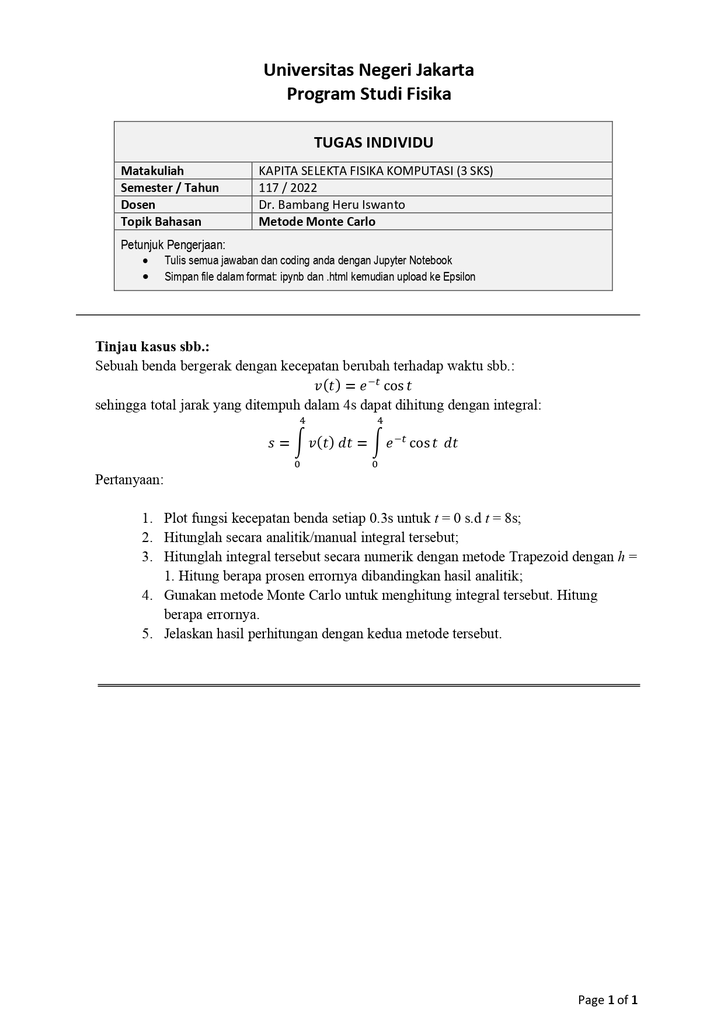

- Nama : Muhammad Rizky Anugrah
- NIM : 1306620089
- Kelas: Fisika B
- Dosen: Dr.rer.nat. Bambang Heru Iswanto

## Fungsi

```python
import numpy as np
import sympy as smp
import matplotlib.pyplot as plt

def f_v(t):
    vt = np.exp(-t)*np.cos(t)
    return vt

def trapezoidal(function_trap,a,b,h):
    if a > b:
        print('the value of b must be bigger than a')
        return 'ErrorValue'
    N = int((b-a)/h)
    func_a = function_trap.subs({sym_t:a}).evalf()
    func_b = function_trap.subs({sym_t:b}).evalf()
    s = 0
    for i in range (1,N):
        s += function_trap.subs({sym_t:i}).evalf()
    IntegralTrap = (h/2)*(func_a +  2*s + func_b)
    div_2 = smp.diff(function_trap,sym_t,2)
    jumlah_div2 = 0
    steps_error = np.arange(a,b,h)
    for i in steps_error:
        jumlah_div2 += div_2.subs({sym_t:((i+(i+h))/2)}).evalf()
    error_Trap = (b-a)/12*h**2*jumlah_div2
    return IntegralTrap, error_Trap

def montecarlo(f,a,b,n,option="uniform"):
    np.random.seed(314159)
    us = np.random.uniform(a, b, n)

    if option=="uniform":
        fs = f(us)
    else:
        c0 = 4 - 2*np.sqrt(2)
        c1 = -6 + 4*np.sqrt(2)
        xs = (-c0 + np.sqrt(2*c1*us + c0**2))/c1
        fs = f(xs)/(c0 + c1*xs)

    fbar, err = stats(fs)
    return (b-a)*fbar, (b-a)*err

def stats(fs):
    n = fs.size
    fbar = np.sum(fs)/n
    fsq = np.sum(fs**2)/n
    varfbar = (fsq - fbar**2)/(n - 1)
    return fbar, np.sqrt(varfbar)

def plotting(X,Y,axis_x,axis_y,judul_tabel):
    fig = plt.figure(figsize=(10,5))
    plt.rcParams.update({'font.size': 15})
    plt.tick_params(colors='red', which='both')
    plt.title('{}'.format(judul_tabel), fontsize = 20, color = 'red')
    plt.xlabel('{}'.format(axis_x), fontsize = 20, color = 'red')
    plt.ylabel('{}'.format(axis_y), fontsize = 20, color = 'red')
    plt.plot(X,Y, 'o-', color = 'red')
    plt.grid()
    plt.show()
```

## Rumus v(t)

```python
t = smp.symbols('t', real=True)
```

```python
func = smp.exp(-t)*smp.cos(t)
func
```

$\displaystyle e^{- t} \cos{\left(t \right)}$

## Rumus s

```python
sym_t = smp.symbols('t')
sym_s = smp.Function('s')
sym_v = smp.Function('v')
```

```python
I = smp.Integral(sym_v(sym_t), (sym_t,0,4))
I
```

$\displaystyle \int\limits_{0}^{4} v{\left(t \right)}\, dt$

```python
I = smp.Integral(smp.exp(-sym_t)*smp.cos(sym_t), (sym_t,0,4))
I
```

$\displaystyle \int\limits_{0}^{4} e^{- t} \cos{\left(t \right)}\, dt$

## Nomor 1

1. Plot fungsi kecepatan benda setiap 0.3s untuk t = 0 s.d t = 8s;

```python
step = np.arange(0,8,0.3)
n = len(step)
nilai_vt = np.zeros([n])
for i in range(n):
    nilai_vt[i] += f_v(step[i])
print(nilai_vt)
```

```
[ 1.00000000e+00  7.07730678e-01  4.52953789e-01  2.52727753e-01
  1.09140058e-01  1.57836031e-02 -3.75562537e-02 -6.18216508e-02
 -6.68948486e-02 -6.07586319e-02 -4.92888241e-02 -3.64213817e-02
 -2.45027781e-02 -1.46942574e-02 -7.35174381e-03 -2.34172981e-03
  7.20094501e-04  2.30443450e-03  2.86664175e-03  2.79292014e-03
  2.38002419e-03  1.83604519e-03  1.29266605e-03  8.22075870e-04
  4.54186458e-04  1.91718576e-04  2.21074231e-05]
```

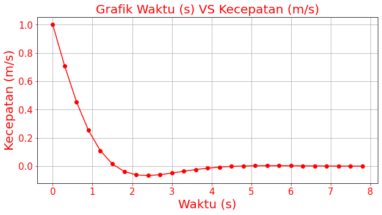

```python
plotting(step,nilai_vt,'Waktu (s)','Kecepatan (m/s)','Grafik Waktu (s) VS Kecepatan (m/s)')
```

## Nomor 2

1. Hitunglah secara analitik/manual integral tersebut;

```python
I = smp.Integral(sym_v(sym_t), (sym_t,0,4))
I
```

$\displaystyle \int\limits_{0}^{4} v{\left(t \right)}\, dt$

```python
vt = smp.exp(-sym_t)*smp.cos(sym_t)
vt
```

$\displaystyle e^{- t} \cos{\left(t \right)}$

```python
Integral = smp.Integral(smp.exp(-sym_t)*smp.cos(sym_t), (sym_t,0,4))
Integral
```

$\displaystyle \int\limits_{0}^{4} e^{- t} \cos{\left(t \right)}\, dt$

```python
s = smp.integrate(vt, (sym_t,0,4))
s
```

$\displaystyle \frac{\sin{\left(4 \right)}}{2 e^{4}} - \frac{\cos{\left(4 \right)}}{2 e^{4}} + \frac{1}{2}$

```python
nilai_s = smp.integrate(vt, (sym_t,0,4)).evalf()
nilai_s
```

$\displaystyle 0.499055289653755$

## Nomor 3

1. Hitunglah integral tersebut secara numerik dengan metode Trapezoid dengan h = 1. Hitung berapa prosen errornya dibandingkan hasil analitik;

```python
a = 0
b = 4
h = 1
```

```python
function_trap = smp.exp(-sym_t)*smp.cos(sym_t)
```

```python
IntegralTrap, error_Trap = trapezoidal(function_trap,a,b,h)
```

```python
print('Integral Trapezoidal = ', IntegralTrap)
print('Error Trapezoidal = ', error_Trap)
```

```
Integral Trapezoidal =  0.587171985981535
Error Trapezoidal =  0.367926902547642
```

```python
persen_error = np.abs((IntegralTrap-nilai_s)/nilai_s)
print('Persen Error Trapezoidal Dibandingkan dengan Analitik = {0:^9.3%}'.format(persen_error))
```

```
Persen Error Trapezoidal Dibandingkan dengan Analitik =  17.657%
```

## Nomor 4

1. Gunakan metode Monte Carlo untuk menghitung integral tersebut. Hitung berapa errornya

```python
for n in 10**np.arange(2,7):
        avu, erru = montecarlo(f_v, 0., 4., n)
        rowf = "{0:7d} {1:1.9f} {2:1.9f}"
        print(rowf.format(n, avu, erru))
```

```
    100 0.457552699 0.102464491
   1000 0.502187521 0.034876860
  10000 0.497405853 0.011282399
 100000 0.495764886 0.003523643
1000000 0.498739255 0.001117778
```

```python
print('Integral Metode Monte Carlo = ', avu)
print('Error Metode Monnte Carlo = ', erru)
```

```
Integral Metode Monte Carlo =  0.498739254681555
Error Metode Monnte Carlo =  0.0011177780277117464
```

```python
persen_error_monte_carlo = np.abs((avu-nilai_s)/nilai_s)
print('Persen Error Metode Monte Carlo Dibandingkan dengan Analitik = {0:^9.3%}'
      .format(persen_error_monte_carlo))
```

```
Persen Error Metode Monte Carlo Dibandingkan dengan Analitik =  0.063%
```

## Nomor 5

1. Jelaskan hasil perhitungan dengan kedua metode tersebut

Berdasarkan perhitungan mennggunakan metode analitik atau manual dengan library sympy diperoleh nilai hasil integral yaitu 0.499055289653755. Jika dibandingkan dengan 2 metode peng-integralan yaitu metode trapezoidal rule dan metode monte carlo maka akan menghasilkan nilai integral yang berbeda. Hasil integral dengan menggunakan metode trapezoidal rule dengan step h = 1 yaitu 0.587171985981535 dengan error trapezoidal sebesar 0.367926902547642. Namun, hasil integral menggunakan metode monte carlo yaitu 0.498739254681555 dengan error metode monte carlo sebesar 0.0011177780277117464. Dengan begitu, jika hasil integral dari kedua metode dibandingkan dengan metode analitik/manual memiliki perbedaan pada persen error yang dihasilkan. Perbandingan persen error trapezoidal dengan analitik/manual yaitu 17.657%. Sedangkan perbandingan persen error metode monte carlo dengan analitik/manual yaitu 0.063%. Oleh karena itu terlihat bahwa hasil integral metode monte carlo lebih mendekati dengan hasil analitik/manual sehingga persen error yang dihasilkan lebih kecil dari metode trapezoidal dan juga error yang yang dihasilkan lebih kecil dibandingkan dengan metode trapezoidal.

## REFERENSI

- Sympy? = Diajarin Mas Difa
- Laprak Fiskom
- Buku = Kiussalas
- Buku = ___book-Alex Gezerlis - Numerical Methods in Physics with Python-(Cambridge Univ Press) (2020)